# Regression and correlation

You should work through the exercises step-by-step, following the instructions carefully. At various points we will interrupt the flow of instructions with a question. Make a note of your answers so that you can complete the MOLE quiz for this week.

### Hedgerows and partridges

Hedgerows are the main nesting habitat of the grey partridge (*Perdix perdix*). A survey was carried out to establish whether the abundance of hedgerows in agricultural land had an effect on the abundance of grey partridge. From an area of agricultural land covering several farms, twelve plots were selected which had land uses as similar as possible but differed in the density of hedgerows (km hedgerow per km<sup>2</sup>). Plots were deliberately selected to cover a wide range of hedgerow densities. The total hedgerow lengths, and exact plot areas, were measured by use of large scale maps. The density of partridges was established by visiting all fields in a study plot once immediately after dawn and once just before dusk, when partridges are feeding and therefore most likely to be seen. Counts of birds observed were made on each visit and the dawn and dusk data were averaged to give a value for partridge abundance for each study plot.

The data are stored in a CSV file PARTRIDG.CSV. Take note: this is a different data set than the one used in the ‘Regression diagnostics’ chapter. The density of hedgerows (km per km<sup>2</sup>) is in the `Hedgerow` variable and the density of partridges (no. per km<sup>2</sup>) is in the `Partridge` variable. Read in the data and take a look at it using the `View` function.

**MOLE question**

Which way round should the variables be?

- Independent (*x*):
- Dependent (*y*):

Use the `lm` function to fit a linear regression model for the relationship between hedgerow density and partridge density. Be sure to assign a name to the resulting model object. Evaluate the assumptions of the model by using the `plot` function to produce: 1) a residuals vs. fitted plot, 2) a normal probability plot, and 3) a scale-location plot.

**MOLE question**

Evaluating assumptions…

1. Are you working with ratio or interval data?
2. If there is a relationship, is it likely to be linear?
3. Are the residuals normally distributed?
4. Does the variance of the residuals remain constant with increasing *y*?

Next, carry out a statistical significance test to evaluate whether the slope of the regression line is different from 0 (use an *F*-test).

**MOLE question**

Summarise the results of your analysis in words.

Finish up by preparing a figure that summarises the data and the best fit line estimated from the regression. Do not use `geom_smooth`!

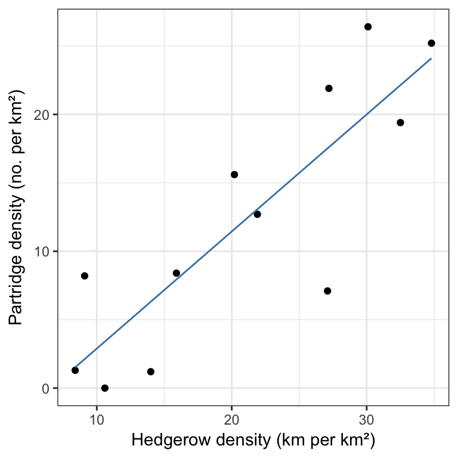

### Analysing associations

Consider the following scenarios amenable to analysis by either simple linear regression, Pearson’s product-moment correlation, or Spearman’s rank correlation:

- Shoe size and height of students in a class. We want to know if shoe size is associated with the height of male students in a class. We measure the shoe size and height from 120 students. You may assume that shoe size is (approximately) measured onn an interval scale.
- Heart rate and age in the crustacean *Daphnia* reared in the lab. We want to know how, on average, heart rate depends on age. Six groups of 10 *Daphnia* are reared to ages 2, 4, 6, 8, 10, 12 days old. The heart rate of each individual is then assayed at their target age.
- Number of plant species and number of herbivorous insect species. We want to know if the diversity of herbivorous insect species is positively associated with plant diversity. 22 randomly located 5x5m study plots were surveyed in a field.
- Order of arrival of dung beetle species on elephant dung and body size. We want to know if larger dung beetle species are better at locating dung. We locate a fresh piece of dung and observe beetles arriving over a period of 3 hours, recording the order of arrival and the weight of each new arrival.
- Percentage bud damage to pear trees by bullfinches. We want to know how much bud damage changes with the distance of trees from thick vegetation at the edge of an orchard (bullfinches aggregate in the thick vegetation). Trees are arranged in rows parallel to the orchard edge and a single tree, selected at random from every row, is sampled for bud damage.
- Density of nesting stork pairs and number of human births. A science reporter from the Daily Mail is struggling to come up with a story. They think storks might deliver babies, so they collect local hospital records of annual births and amateur ornithology records of number of stork sitings covering a 20 year period in the Sheffield area.
- Colour of the waterbug *Sigara falleni* from a series of ponds and colour of the sediment from each pond. We want to know if the colour of the waterbug *Sigara falleni* (ranked from dark to light) is related to the colour of the sediment (ranked on the same scale) from each pond.
- Number of copulations achieved by male elephant seals and dominance. We want to know if higher-ranked males achieve more matings. Rank is established by observing the outcome of aggressive interactions between males and the number of matings is observed over a two week period in the breeding season.

**MOLE question**

Suggest the type of analysis—and the dependent and independent variables where relevant—likely to be appropriate in each case. You may assume that if there is a relationship it will be roughly linear over the range considered.

### Diagnosing problems

We have constructed four artificial data sets to practice interpreting regression diagnostic plots. Each case study corresponds to a hypothetical study where we wish to understand the dependence of numeric variable $y$ on numeric variable $x$. This is a simple linear regression setting where $y$ is the dependent variable and $x$ is the independent variable.

All four data sets are stored in one file called SIMPLEREG_EGS.CSV—the dependent variable is stored in `y`, and the independent variable is stored in `x`. Each case study is identified by the `Case` variable (values: ‘A’, ‘B’, ‘C’ and ‘D’).

Fit a linear regression model to each case in turn, and then use the `plot` function to produce the residuals vs. fitted plot, the normal probability plot, and the scale-location plot. Hint: you will need to first extract the required subset of data using the `filter` function from **dplyr** function.

**MOLE question**

For each of the four case studies, make a note of your answer to the following questions:

Is the linearity assumption satisfied?

Is the normality assumption satisfied?

Is the constant variance assumption satisfied?